# Take-home Exercise 3

A new article created using the Distill format.

LIU Zhenglin https://www.linkedin.com/in/zhenglin-liu-a86aa5219/ (SMU SCIS)https://scis.smu.edu.sg/  
2022-05-15

# Import packages and data

```r
packages = c('tidyverse','skimr','ggrepel','patchwork',
             'lubridate', 'trelliscopejs', 'zoo',
             'DT', 'tidyr', 'gganimate', 'gifski',
             'gapminder', 'ggridges','ggiraph')

for(p in packages){
  if(!require(p, character.only =T)){
    install.packages(p)
    }
  library(p, character.only =T)
}
```

### Importing Data

```r
fj <- read_csv("E:/data/Journals/FinancialJournal.csv")
fj
```

```
# A tibble: 1,856,330 x 4
   participantId timestamp           category  amount
           <dbl> <dttm>              <chr>      <dbl>
 1             0 2022-03-01 00:00:00 Wage      2473.
 2             0 2022-03-01 00:00:00 Shelter   -555.
 3             0 2022-03-01 00:00:00 Education  -38.0
 4             1 2022-03-01 00:00:00 Wage      2047.
 5             1 2022-03-01 00:00:00 Shelter   -555.
 6             1 2022-03-01 00:00:00 Education  -38.0
 7             2 2022-03-01 00:00:00 Wage      2437.
 8             2 2022-03-01 00:00:00 Shelter   -557.
 9             2 2022-03-01 00:00:00 Education  -12.8
10             3 2022-03-01 00:00:00 Wage      2367.
# ... with 1,856,320 more rows
```

```r
fj %>%
  filter(participantId == 0)
```

```
# A tibble: 1,958 x 4
   participantId timestamp           category   amount
           <dbl> <dttm>              <chr>       <dbl>
 1             0 2022-03-01 00:00:00 Wage      2473.
 2             0 2022-03-01 00:00:00 Shelter   -555.
 3             0 2022-03-01 00:00:00 Education  -38.0
 4             0 2022-03-01 00:00:00 Shelter   -555.
 5             0 2022-03-01 00:00:00 Education  -38.0
 6             0 2022-03-01 08:25:00 Wage         4.28
 7             0 2022-03-01 08:50:00 Food        -4.17
 8             0 2022-03-01 16:25:00 Wage       386.
 9             0 2022-03-01 16:50:00 Food        -4.17
10             0 2022-03-01 17:20:00 Wage        21.4
# ... with 1,948 more rows
```

We can see there are 4 columns in Financial Journal Dataset: ● participantId (integer): unique ID corresponding to the participant affected ● timestamp (datetime): the time when the check-in was logged ● category (string factor): a string describing the expense category, one of{“Education”, “Food”, “Recreation”, “RentAdjustment”, “Shelter”, “Wage”} ● amount (double): the amount of the transaction 1. As for the category column, it contains 6 different kind of financial factors, split this column in to 6 different columns which shows one of these factors can help us to summarize and analyze the financial situation of participants, so this is the first task of our data wrangling. 2. This dataset contains nearly 2 million rows, one participant have 1958 rows to present his or her financial situation, as for analysis, the timestamp is too large, so we need to set a time interval for better analysis, we choose one month as the time interval.

# Data Wrangling for Financial Journal.

### 1. Time interval

```r
fj_t <- fj %>%
  mutate(yearmonth = format(as.Date(timestamp), "%Y.%m"))
fj_t
```

```
# A tibble: 1,856,330 x 5
   participantId timestamp           category  amount yearmonth
           <dbl> <dttm>              <chr>      <dbl> <chr>
 1             0 2022-03-01 00:00:00 Wage      2473.  2022.03
 2             0 2022-03-01 00:00:00 Shelter   -555.  2022.03
 3             0 2022-03-01 00:00:00 Education  -38.0 2022.03
 4             1 2022-03-01 00:00:00 Wage      2047.  2022.03
 5             1 2022-03-01 00:00:00 Shelter   -555.  2022.03
 6             1 2022-03-01 00:00:00 Education  -38.0 2022.03
 7             2 2022-03-01 00:00:00 Wage      2437.  2022.03
 8             2 2022-03-01 00:00:00 Shelter   -557.  2022.03
 9             2 2022-03-01 00:00:00 Education  -12.8 2022.03
10             3 2022-03-01 00:00:00 Wage      2367.  2022.03
# ... with 1,856,320 more rows
```

```r
fj_t %>%
  filter(participantId == 0) %>%
  filter(category == "Education")
```

```
# A tibble: 16 x 5
   participantId timestamp           category  amount yearmonth
           <dbl> <dttm>              <chr>      <dbl> <chr>
 1             0 2022-03-01 00:00:00 Education  -38.0 2022.03
 2             0 2022-03-01 00:00:00 Education  -38.0 2022.03
 3             0 2022-04-01 00:00:00 Education  -38.0 2022.04
 4             0 2022-05-01 00:00:00 Education  -38.0 2022.05
 5             0 2022-06-01 00:00:00 Education  -38.0 2022.06
 6             0 2022-07-01 00:00:00 Education  -38.0 2022.07
 7             0 2022-08-01 00:00:00 Education  -38.0 2022.08
 8             0 2022-09-01 00:00:00 Education  -38.0 2022.09
 9             0 2022-10-01 00:00:00 Education  -38.0 2022.10
10             0 2022-11-01 00:00:00 Education  -38.0 2022.11
11             0 2022-12-01 00:00:00 Education  -38.0 2022.12
12             0 2023-01-01 00:00:00 Education  -38.0 2023.01
13             0 2023-02-01 00:00:00 Education  -38.0 2023.02
14             0 2023-03-01 00:00:00 Education  -38.0 2023.03
15             0 2023-04-01 00:00:00 Education  -38.0 2023.04
16             0 2023-05-01 00:00:00 Education  -38.0 2023.05
```

### Pivot Original Dataframe

Before pivot the financial journal, we need to calculate the monthly financial situation for each participant in each cost or revenue area. For dealing with this problem, we need to combine [**group_by**](https://dplyr.tidyverse.org/reference/group_by.html) and [**summarise**](https://dplyr.tidyverse.org/reference/summarise.html) functions to realize our aim.

```r
fj_c <- fj_t %>%
  group_by(participantId, category, yearmonth) %>%
  summarise(monthly_financial = sum(amount))
fj_c
```

```
# A tibble: 55,498 x 4
# Groups:   participantId, category [4,142]
   participantId category  yearmonth monthly_financial
           <dbl> <chr>     <chr>                 <dbl>
 1             0 Education 2022.03               -76.0
 2             0 Education 2022.04               -38.0
 3             0 Education 2022.05               -38.0
 4             0 Education 2022.06               -38.0
 5             0 Education 2022.07               -38.0
 6             0 Education 2022.08               -38.0
 7             0 Education 2022.09               -38.0
 8             0 Education 2022.10               -38.0
 9             0 Education 2022.11               -38.0
10             0 Education 2022.12               -38.0
# ... with 55,488 more rows
```

```r
fj_p <- fj_c %>%
  pivot_wider(names_from = category, values_from = monthly_financial)
fj_p[is.na(fj_p)] = 0
fj_p
```

```
# A tibble: 13,331 x 8
# Groups:   participantId [1,011]
   participantId yearmonth Education  Food Recreation Shelter   Wage
           <dbl> <chr>         <dbl> <dbl>      <dbl>   <dbl>  <dbl>
 1             0 2022.03       -76.0 -268.     -349.   -1110. 11932.
 2             0 2022.04       -38.0 -266.     -219.    -555.  8637.
 3             0 2022.05       -38.0 -265.     -383.    -555.  9048.
 4             0 2022.06       -38.0 -257.     -466.    -555.  9048.
 5             0 2022.07       -38.0 -270.    -1070.    -555.  8637.
 6             0 2022.08       -38.0 -262.     -314.    -555.  9459.
 7             0 2022.09       -38.0 -256.     -295.    -555.  9048.
 8             0 2022.10       -38.0 -267.      -25.0   -555.  8637.
 9             0 2022.11       -38.0 -261.     -377.    -555.  9048.
10             0 2022.12       -38.0 -266.     -357.    -555.  9048.
# ... with 13,321 more rows, and 1 more variable:
#   RentAdjustment <dbl>
```

```r
fj_p <- fj_p %>%
  mutate(monthly_cost = Education + Food + Recreation + Shelter) %>%
  mutate(monthly_revenue = Wage + RentAdjustment) %>%
  mutate(monthly_balance = monthly_revenue + monthly_cost)
fj_p
```

```
# A tibble: 13,331 x 11
# Groups:   participantId [1,011]
   participantId yearmonth Education  Food Recreation Shelter   Wage
           <dbl> <chr>         <dbl> <dbl>      <dbl>   <dbl>  <dbl>
 1             0 2022.03       -76.0 -268.     -349.   -1110. 11932.
 2             0 2022.04       -38.0 -266.     -219.    -555.  8637.
 3             0 2022.05       -38.0 -265.     -383.    -555.  9048.
 4             0 2022.06       -38.0 -257.     -466.    -555.  9048.
 5             0 2022.07       -38.0 -270.    -1070.    -555.  8637.
 6             0 2022.08       -38.0 -262.     -314.    -555.  9459.
 7             0 2022.09       -38.0 -256.     -295.    -555.  9048.
 8             0 2022.10       -38.0 -267.      -25.0   -555.  8637.
 9             0 2022.11       -38.0 -261.     -377.    -555.  9048.
10             0 2022.12       -38.0 -266.     -357.    -555.  9048.
# ... with 13,321 more rows, and 4 more variables:
#   RentAdjustment <dbl>, monthly_cost <dbl>, monthly_revenue <dbl>,
#   monthly_balance <dbl>
```

```r
part <- read_csv("E:/data/Attributes/Participants.csv")
```

```r
fj_join <- fj_p %>%
  left_join(part, by = "participantId")
fj_join
```

```
# A tibble: 13,331 x 17
# Groups:   participantId [1,011]
   participantId yearmonth Education  Food Recreation Shelter   Wage
           <dbl> <chr>         <dbl> <dbl>      <dbl>   <dbl>  <dbl>
 1             0 2022.03       -76.0 -268.     -349.   -1110. 11932.
 2             0 2022.04       -38.0 -266.     -219.    -555.  8637.
 3             0 2022.05       -38.0 -265.     -383.    -555.  9048.
 4             0 2022.06       -38.0 -257.     -466.    -555.  9048.
 5             0 2022.07       -38.0 -270.    -1070.    -555.  8637.
 6             0 2022.08       -38.0 -262.     -314.    -555.  9459.
 7             0 2022.09       -38.0 -256.     -295.    -555.  9048.
 8             0 2022.10       -38.0 -267.      -25.0   -555.  8637.
 9             0 2022.11       -38.0 -261.     -377.    -555.  9048.
10             0 2022.12       -38.0 -266.     -357.    -555.  9048.
# ... with 13,321 more rows, and 10 more variables:
#   RentAdjustment <dbl>, monthly_cost <dbl>, monthly_revenue <dbl>,
#   monthly_balance <dbl>, householdSize <dbl>, haveKids <lgl>,
#   age <dbl>, educationLevel <chr>, interestGroup <chr>,
#   joviality <dbl>
```

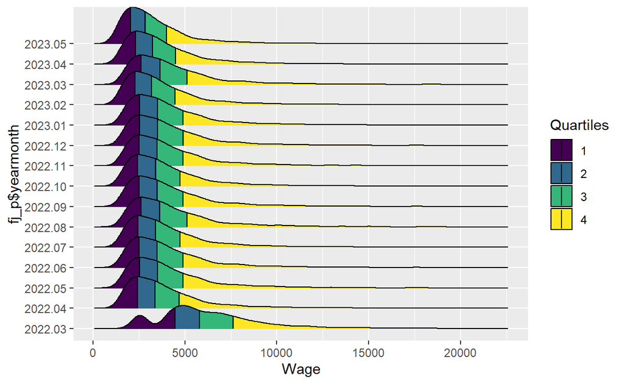

```r
ggplot(fj_p, aes(x=Wage, y=fj_p$yearmonth, fill = factor(stat(quantile)))) +
  stat_density_ridges(
    geom = "density_ridges_gradient", calc_ecdf = TRUE,
    quantiles = 4, quantile_lines = TRUE
  ) +
  scale_fill_viridis_d(name = "Quartiles")
```

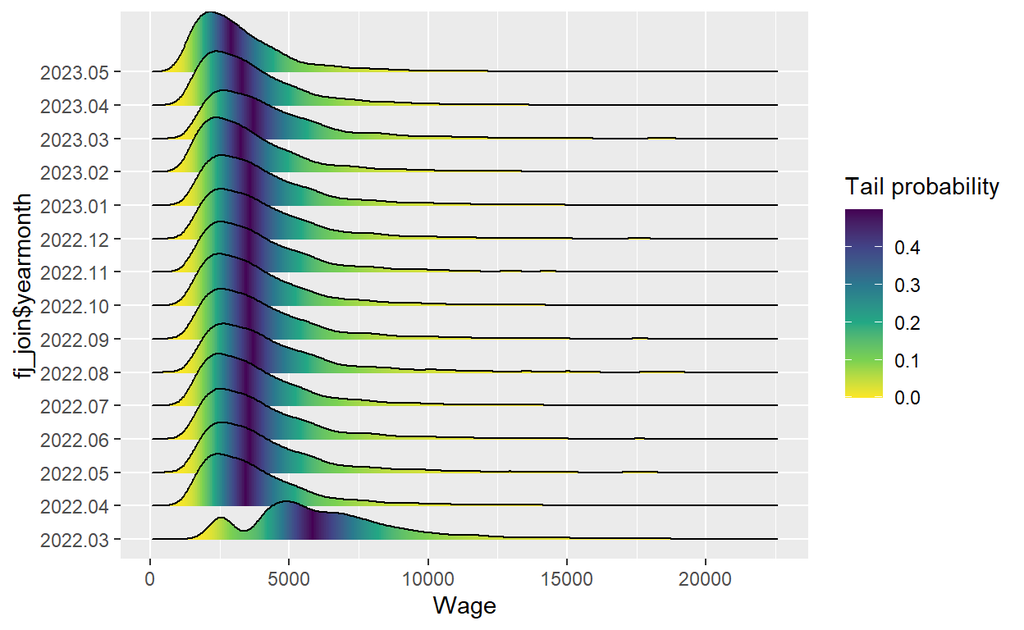

```r
ggplot(fj_join, aes(x = Wage, y = fj_join$yearmonth, fill = 0.5 - abs(0.5 - stat(ecdf)))) +
  stat_density_ridges(geom = "density_ridges_gradient", calc_ecdf = TRUE) +
  scale_fill_viridis_c(name = "Tail probability", direction = -1)
```

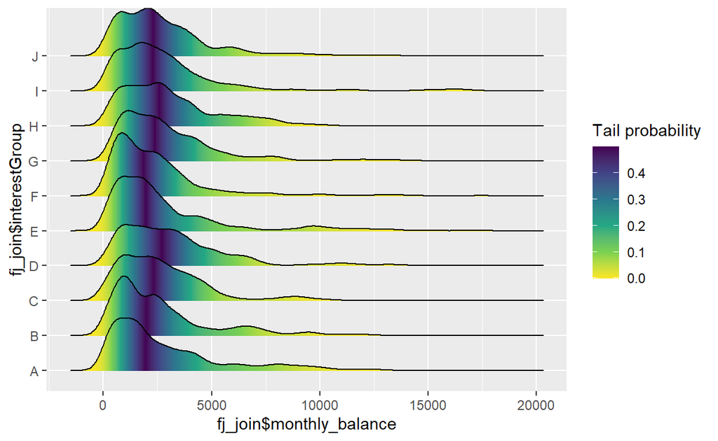

```r
ggplot(fj_join, aes(x = fj_join$monthly_balance, y = fj_join$interestGroup, fill = 0.5 - abs(0.5 - stat(ecdf)))) +
  stat_density_ridges(geom = "density_ridges_gradient", calc_ecdf = TRUE) +
  scale_fill_viridis_c(name = "Tail probability", direction = -1)
```

```r
tooltip <- function(y, ymax, accuracy = .0001) {
  mean <- scales::number(y, accuracy = accuracy)
  sem <- scales::number(ymax - y, accuracy = accuracy)
  paste("Mean cost rate:", mean, "+/-", sem)
}
gg_point <- ggplot(data=fj_join,
                   aes(x = fj_join$educationLevel),
) +
  stat_summary(aes(y = abs(fj_join$monthly_cost)/fj_join$monthly_revenue,
                   tooltip = after_stat(
                     tooltip(y, ymax))),
    fun.data = "mean_se",
    geom = GeomInteractiveCol,
    fill = "light blue"
  ) +
  stat_summary(aes(y = abs(fj_join$monthly_cost)/fj_join$monthly_revenue),
    fun.data = mean_se,
    geom = "errorbar", width = 0.2, size = 0.2
  )
girafe(ggobj = gg_point,
       width_svg = 8,
       height_svg = 8*0.618)
```

[interactive chart not shown]